# Szeregi czasowe

Michał Żychowski

2023-05-25

## Podstawowa analiza

W pierwszej kolejności, zaimportujmy dane oraz niezbędne biblioteki.

```r
library(readxl)
dane_pierwotne <-read_excel("../data/dane.xlsx",col_types = c("text", "numeric"))
head(dane_pierwotne)
library(forecast)
library(tseries)
library(fBasics)
library(timeSeries)
library(lmtest)
library(TTR)
```

Następnie przygotujmy dane do analizy i wygenerujmy wykres.

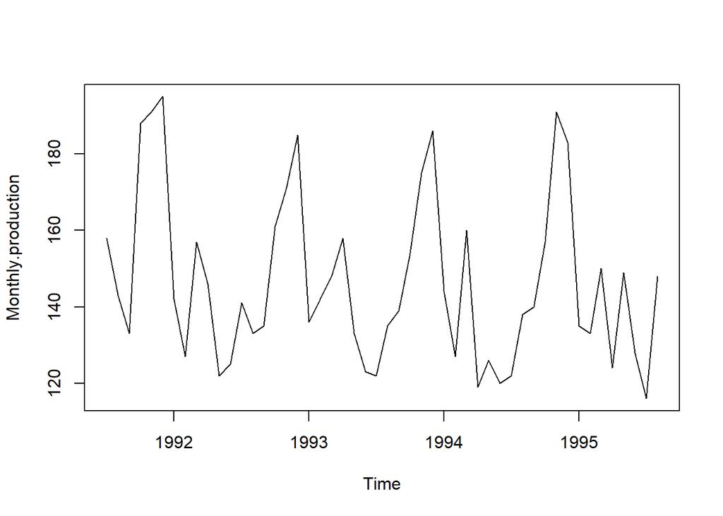

```r
dane <- data.frame(dane_pierwotne)
X <- ts(dane[2], start = c(1991,7),frequency = 12)
plot.ts(X)
```

Następnie sprawdzamy czy nasz szereg jest stacjonarny oraz czy jest eksplozywny

```r
stationarity_test <-adf.test(X,alternative = "stationary",k = 2)
ifelse(stationarity_test$p.value<0.05,"Szereg jest stacjonarny","Szereg jest niestacjonarny")

explosive_test <-adf.test(X,alternative = "explosive",k = 2)
ifelse(explosive_test$p.value<0.05,"Szereg jest eksplozywny","Szereg jest nieeksplozywny")
```

```
## [1] "Szereg jest stacjonarny"
## [1] "Szereg jest nieeksplozywny"
```

Testujemy Trend

```r
#testujemy trend
trend_test <- kpss.test(X,null="Trend",lshort = TRUE)
ifelse(trend_test$p.value<0.05,"Szereg ma trend","Szereg nie ma trendu")
```

```
## [1] "Szereg nie ma trendu"
```

Ze względu na stacjonarność naszego szeregu, teraz możemy przejść do sprawdzenia podstawowych statystyk dla niego.

```r
basic_stats<-basicStats(X,ci=0.95)
basic_stats
```

```
##             Monthly.production
## nobs                 50.000000
## NAs                   0.000000
## Minimum             116.000000
## Maximum             195.000000
## 1. Quartile         129.250000
## 3. Quartile         157.750000
## Mean                146.280000
## Median              141.500000
## Sum                7314.000000
## SE Mean               3.097470
## LCL Mean            140.055402
## UCL Mean            152.504598
## Variance            479.715918
## Stdev                21.902418
## Skewness              0.762517
## Kurtosis             -0.494176
```

## Dekompozycja szeregu

Dla przeprowadzenia dekompozycji szeregu, musimy ustalić, czy jest on addytywny czy multiplikatywny. Możemy to ocenić, analizując wykres naszego szeregu.

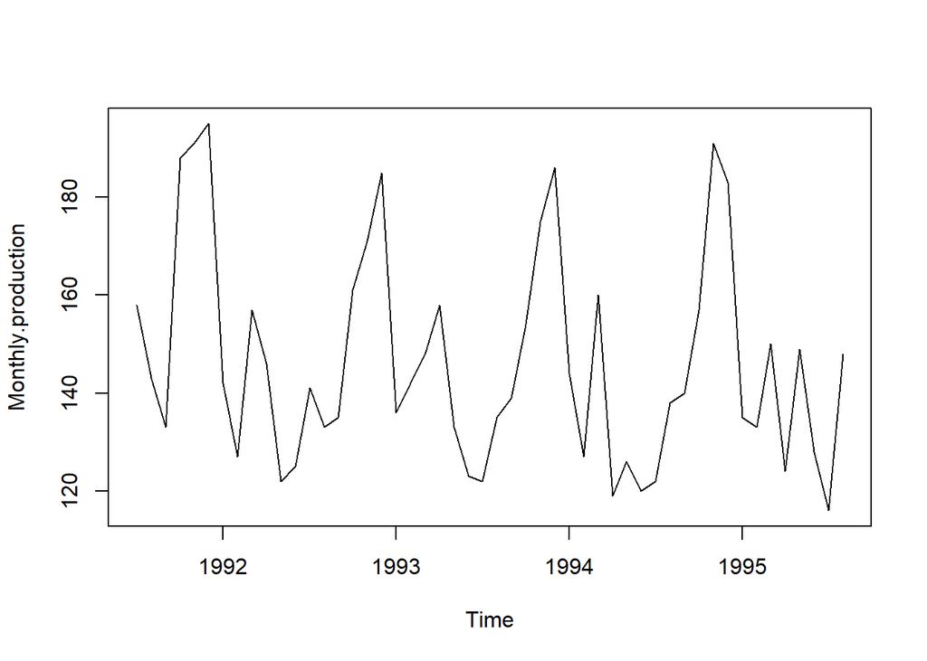

```r
plot(X)
```

Ze względu na stałą amplitudę wahań naszego szeregu, można stwierdzić, że ma on model addytywny.

Teraz, po ustaleniu modelu naszego szeregu, przystępujemy do jego dekompozycji.

```r
dane_zdekomponowane <- decompose(X,type="additive",filter = NULL)
```

Po przeprowadzeniu dekompozycji, możemy sporządzić poniższe wykresy.

### Sezonowość szeregu

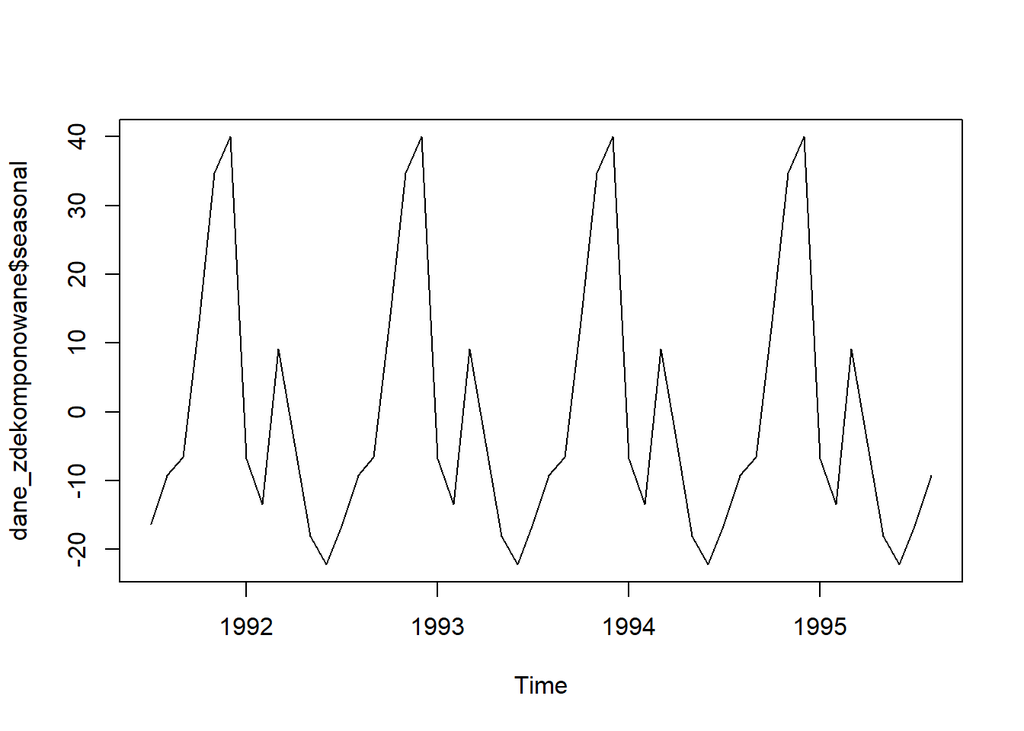

### Trend szeregu

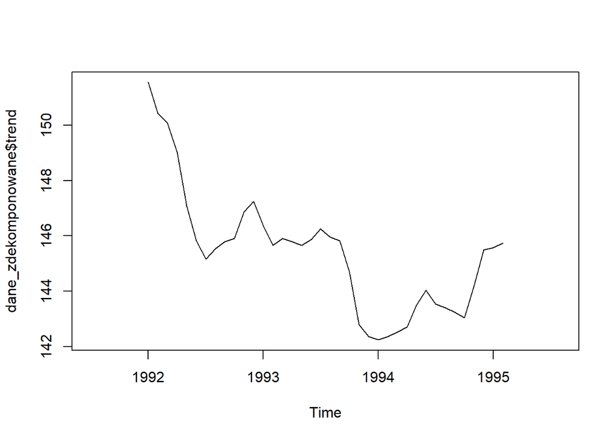

### Odchylenia losowe

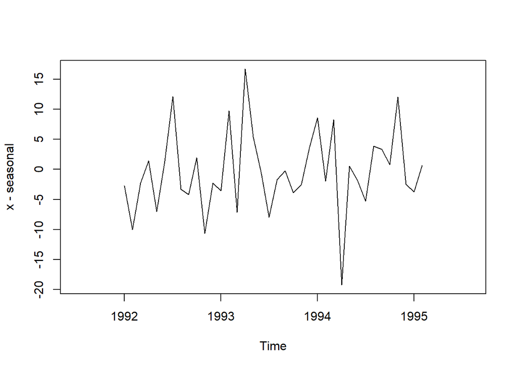

### Podusmowanie wykresów

Widzimy teraz wykresy sezowności, trendu oraz wahań losowych

## Tworzenie modelu

Z uwagi na charakter naszego szeregu do stworzenia możemy użyć metody Holta-Wintersa. Z wyżej wyciągniętych wniosków możemy stwierdzić, że należy użyć w tej metodzie parametrów Alfa, Beta i Gamma

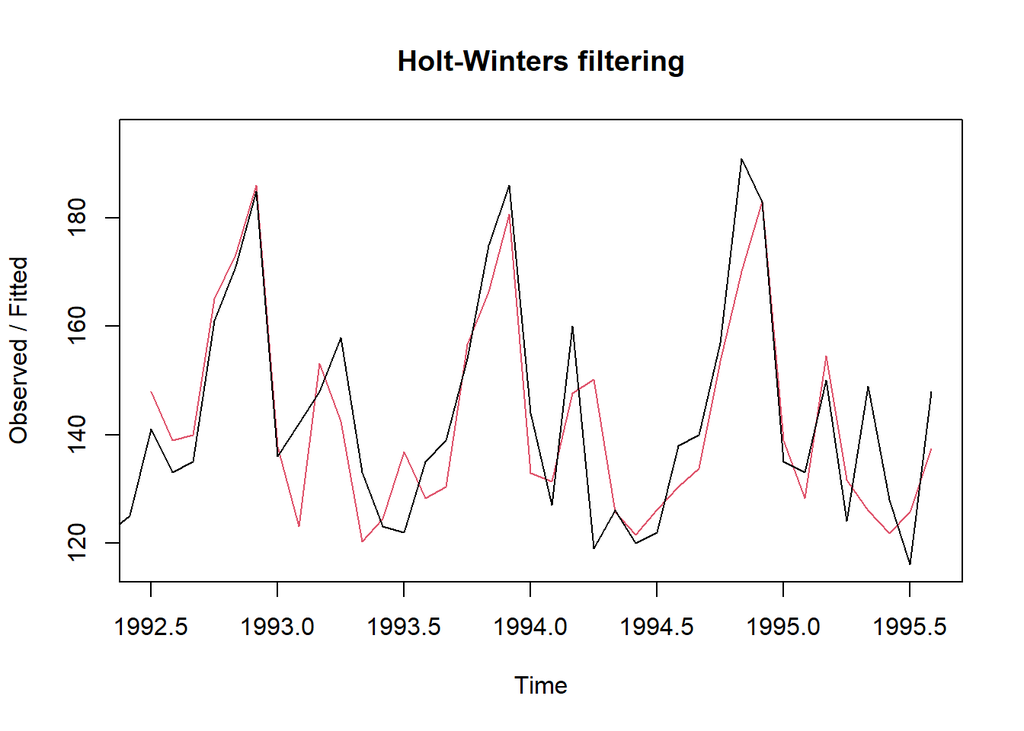

```r
X2 <- HoltWinters(X,seasonal = "additive")
plot(X2)
```

## Przewidywwany trend

Po uzyskaniu naszego modelu, możemy teraz spróbować przewidzieć zachowanie tego zjawiska na przestrzeni na przykład 12 miesięcy, jak to przedstawiono poniżej.

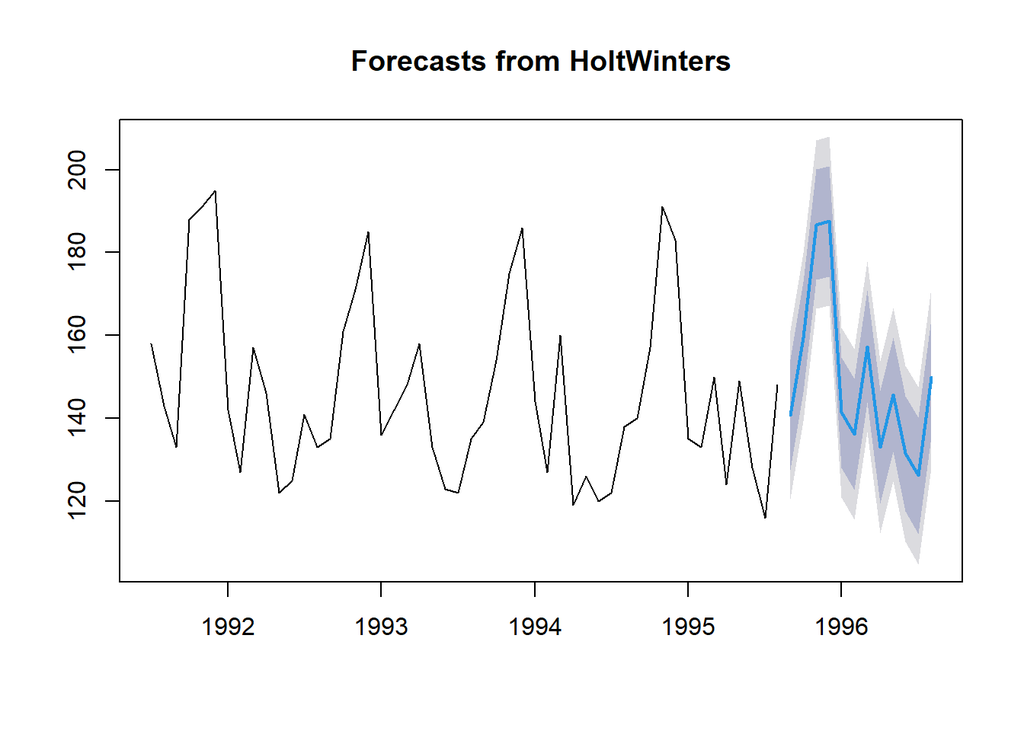

```r
XForecast <- forecast(X2,h=12)
plot(XForecast)
```

## Testowanie prognozy

Po uzyskaniu prognozy, możemy przeprowadzić na niej testy ACF oraz test Ljung-Box w celu sprawdzenia autokorelacji.

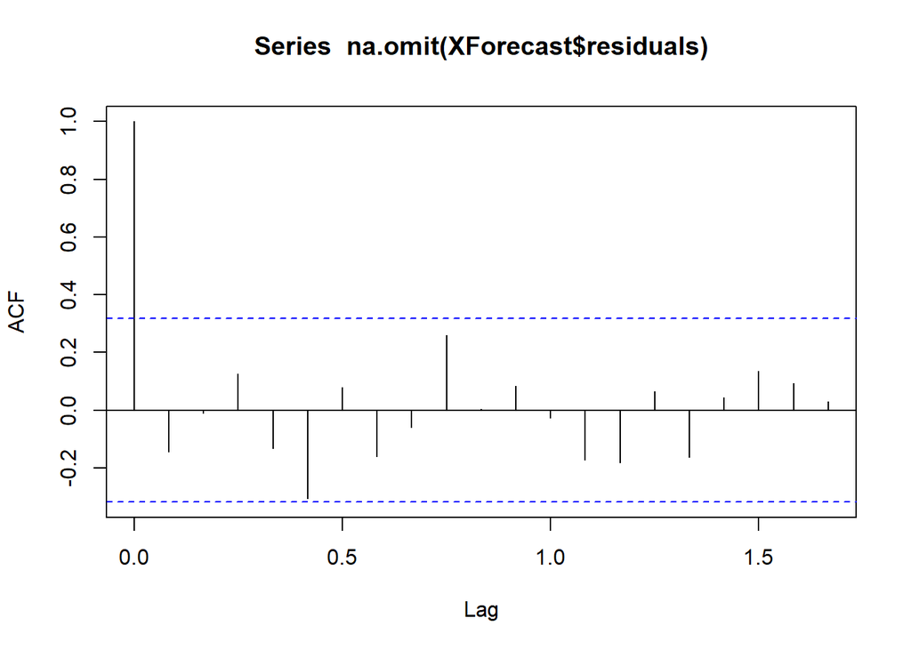

```r
acf(na.omit(XForecast$residuals), lag.max=20)
```

```r
box_test<-Box.test(XForecast$residuals, lag=20, type="Ljung-Box")
ifelse(box_test$p.value<0.05,"Występuje istotna autokorelacja w błędch prognozy","Zerowa autokorelacja w błędach prognozy")
```

```
## [1] "Zerowa autokorelacja w błędach prognozy"
```

## Wnioski

Jak można zauważyć na powyższym, nie występują żadne autokorelacje, a wszystkie dotychczas przeprowadzone testy nie wykazały żadnych nieprawidłowości. Na podstawie tego można stwierdzić, że stworzona prognoza jest całkowicie poprawna.